# Project: Investigate a Dataset - [TMDB Movie Dataset]

- Introduction
- Data Wrangling
- Exploratory Data Analysis
- Conclusions

## Introduction

### Dataset Description

> This project examines the TMDB movies dataset, a collection of movies of various genre released between the timeline of 1960 and 2015. The dataset contains the following attributes:
> - movie_id and imdb_id - The identifiers for each movie.
> - cast - The name of the primary actors of the movie.
> - director - The name of the director of the movie.
> - budget - The budgeted amount allocated for production of the movie .
> - genre - The genre of the movie.
> - homepage - The website of the movie.
> - keywords - The tags related to the movie's content.
> - original_title - The initial release title of the movie.
> - overview - A summary description of the movie.
> - popularity - The popularity count of the movies.
> - production_companies - The name of the companies involved in the production of the movie.
> - production_countries - The country in which the movie was produced.
> - release_date - The date on which the movie was released to the market.
> - revenue - The total revenue generated by the movie.
> - runtime - The movie's duration in minutes.
> - tagline - The movie's tag.
> - vote_average - The average ratings of the movie.
> - budget_adj - The amount of the budget when converted to dollar rate in 2010.
> - revenue_adj - The amount of the revenue generated when converted to dollar rate in 2010.

### Question(s) for Analysis

> In this project our analysis shall be centred around the popularity of each movie as such our primary variable for analysis will be the "popularity" variable either as an independent or dependent variable in relation to other variables in the dataset.  
> Popularity will be taken as a dependent variable in examining its relationship with (1) Budget (2) Genre (3) Runtime (4) Vote count.  
> It will be taken as an independent variable in examining its relationsip with (1) Revenue (2) Profit The questions will be looking into includes:
> - What is the distribution of the Popularity variable?
> - What is the relationship between Budget and Popularity?
> - What is the relationship between Genre and Popularity?
> - What is the relationship between Runtime and Popularity?
> - What is the relationship between Vote Count and Popularity?
> - What is the relationship between Popularity and Revenue?
> - What is the relationship between Popularity and Profit?

```python
#import the needed libraries
import numpy as np
import pandas as pd
import matplotlib.pyplot as plt
import seaborn as sns
%matplotlib inline
```

## Data Wrangling

> In this section we will import the dataset and examine the data

```python
movie_dataset = pd.read_csv('tmdb-movies.csv')
```

```python
movie_dataset.head()
```

|  | id | imdb_id | popularity | budget | revenue | original_title | cast | homepage | director | tagline | ... | overview | runtime | genres | production_companies | release_date | vote_count | vote_average | release_year | budget_adj | revenue_adj |
| --- | --- | --- | --- | --- | --- | --- | --- | --- | --- | --- | --- | --- | --- | --- | --- | --- | --- | --- | --- | --- | --- |
| 0 | 135397 | tt0369610 | 32.985763 | 150000000 | 1513528810 | Jurassic World | Chris Pratt\|Bryce Dallas Howard\|Irrfan Khan\|Vi... | http://www.jurassicworld.com/ | Colin Trevorrow | The park is open. | ... | Twenty-two years after the events of Jurassic ... | 124 | Action\|Adventure\|Science Fiction\|Thriller | Universal Studios\|Amblin Entertainment\|Legenda... | 6/9/15 | 5562 | 6.5 | 2015 | 1.379999e+08 | 1.392446e+09 |
| 1 | 76341 | tt1392190 | 28.419936 | 150000000 | 378436354 | Mad Max: Fury Road | Tom Hardy\|Charlize Theron\|Hugh Keays-Byrne\|Nic... | http://www.madmaxmovie.com/ | George Miller | What a Lovely Day. | ... | An apocalyptic story set in the furthest reach... | 120 | Action\|Adventure\|Science Fiction\|Thriller | Village Roadshow Pictures\|Kennedy Miller Produ... | 5/13/15 | 6185 | 7.1 | 2015 | 1.379999e+08 | 3.481613e+08 |
| 2 | 262500 | tt2908446 | 13.112507 | 110000000 | 295238201 | Insurgent | Shailene Woodley\|Theo James\|Kate Winslet\|Ansel... | http://www.thedivergentseries.movie/#insurgent | Robert Schwentke | One Choice Can Destroy You | ... | Beatrice Prior must confront her inner demons ... | 119 | Adventure\|Science Fiction\|Thriller | Summit Entertainment\|Mandeville Films\|Red Wago... | 3/18/15 | 2480 | 6.3 | 2015 | 1.012000e+08 | 2.716190e+08 |
| 3 | 140607 | tt2488496 | 11.173104 | 200000000 | 2068178225 | Star Wars: The Force Awakens | Harrison Ford\|Mark Hamill\|Carrie Fisher\|Adam D... | http://www.starwars.com/films/star-wars-episod... | J.J. Abrams | Every generation has a story. | ... | Thirty years after defeating the Galactic Empi... | 136 | Action\|Adventure\|Science Fiction\|Fantasy | Lucasfilm\|Truenorth Productions\|Bad Robot | 12/15/15 | 5292 | 7.5 | 2015 | 1.839999e+08 | 1.902723e+09 |
| 4 | 168259 | tt2820852 | 9.335014 | 190000000 | 1506249360 | Furious 7 | Vin Diesel\|Paul Walker\|Jason Statham\|Michelle ... | http://www.furious7.com/ | James Wan | Vengeance Hits Home | ... | Deckard Shaw seeks revenge against Dominic Tor... | 137 | Action\|Crime\|Thriller | Universal Pictures\|Original Film\|Media Rights ... | 4/1/15 | 2947 | 7.3 | 2015 | 1.747999e+08 | 1.385749e+09 |

5 rows × 21 columns

```python
movie_dataset.shape
```

```
(10866, 21)
```

```python
movie_dataset.info()
```

```
<class 'pandas.core.frame.DataFrame'>
RangeIndex: 10866 entries, 0 to 10865
Data columns (total 21 columns):
 #   Column                Non-Null Count  Dtype
---  ------                --------------  -----
 0   id                    10866 non-null  int64
 1   imdb_id               10856 non-null  object
 2   popularity            10866 non-null  float64
 3   budget                10866 non-null  int64
 4   revenue               10866 non-null  int64
 5   original_title        10866 non-null  object
 6   cast                  10790 non-null  object
 7   homepage              2936 non-null   object
 8   director              10822 non-null  object
 9   tagline               8042 non-null   object
 10  keywords              9373 non-null   object
 11  overview              10862 non-null  object
 12  runtime               10866 non-null  int64
 13  genres                10843 non-null  object
 14  production_companies  9836 non-null   object
 15  release_date          10866 non-null  object
 16  vote_count            10866 non-null  int64
 17  vote_average          10866 non-null  float64
 18  release_year          10866 non-null  int64
 19  budget_adj            10866 non-null  float64
 20  revenue_adj           10866 non-null  float64
dtypes: float64(4), int64(6), object(11)
memory usage: 1.7+ MB
```

### Data Cleaning

> In this section will clean our dataset. We will examine the dataset for null and duplicate values and clean them as appropriate for our analysis.

```python
movie_dataset.isnull().sum().sum()
```

```
13434
```

```python
movie_dataset.isnull().sum()
```

```
id                         0
imdb_id                   10
popularity                 0
budget                     0
revenue                    0
original_title             0
cast                      76
homepage                7930
director                  44
tagline                 2824
keywords                1493
overview                   4
runtime                    0
genres                    23
production_companies    1030
release_date               0
vote_count                 0
vote_average               0
release_year               0
budget_adj                 0
revenue_adj                0
dtype: int64
```

```python
movie_dataset.drop(["homepage","tagline","keywords","production_companies"], axis=1, inplace=True)
```

```python
movie_dataset.info()
```

```
<class 'pandas.core.frame.DataFrame'>
RangeIndex: 10866 entries, 0 to 10865
Data columns (total 17 columns):
 #   Column          Non-Null Count  Dtype
---  ------          --------------  -----
 0   id              10866 non-null  int64
 1   imdb_id         10856 non-null  object
 2   popularity      10866 non-null  float64
 3   budget          10866 non-null  int64
 4   revenue         10866 non-null  int64
 5   original_title  10866 non-null  object
 6   cast            10790 non-null  object
 7   director        10822 non-null  object
 8   overview        10862 non-null  object
 9   runtime         10866 non-null  int64
 10  genres          10843 non-null  object
 11  release_date    10866 non-null  object
 12  vote_count      10866 non-null  int64
 13  vote_average    10866 non-null  float64
 14  release_year    10866 non-null  int64
 15  budget_adj      10866 non-null  float64
 16  revenue_adj     10866 non-null  float64
dtypes: float64(4), int64(6), object(7)
memory usage: 1.4+ MB
```

```python
movie_dataset.isnull().sum().sum()
```

```
157
```

```python
movie_dataset.dropna(inplace=True)
```

```python
movie_dataset.info()
```

```
<class 'pandas.core.frame.DataFrame'>
Int64Index: 10725 entries, 0 to 10865
Data columns (total 17 columns):
 #   Column          Non-Null Count  Dtype
---  ------          --------------  -----
 0   id              10725 non-null  int64
 1   imdb_id         10725 non-null  object
 2   popularity      10725 non-null  float64
 3   budget          10725 non-null  int64
 4   revenue         10725 non-null  int64
 5   original_title  10725 non-null  object
 6   cast            10725 non-null  object
 7   director        10725 non-null  object
 8   overview        10725 non-null  object
 9   runtime         10725 non-null  int64
 10  genres          10725 non-null  object
 11  release_date    10725 non-null  object
 12  vote_count      10725 non-null  int64
 13  vote_average    10725 non-null  float64
 14  release_year    10725 non-null  int64
 15  budget_adj      10725 non-null  float64
 16  revenue_adj     10725 non-null  float64
dtypes: float64(4), int64(6), object(7)
memory usage: 1.5+ MB
```

```python
movie_dataset.describe()
```

|  | id | popularity | budget | revenue | runtime | vote_count | vote_average | release_year | budget_adj | revenue_adj |
| --- | --- | --- | --- | --- | --- | --- | --- | --- | --- | --- |
| count | 10725.000000 | 10725.000000 | 1.072500e+04 | 1.072500e+04 | 10725.000000 | 10725.000000 | 10725.000000 | 10725.000000 | 1.072500e+04 | 1.072500e+04 |
| mean | 65182.327925 | 0.652852 | 1.481473e+07 | 4.034253e+07 | 102.502471 | 219.933054 | 5.964317 | 2001.255012 | 1.777804e+07 | 5.203541e+07 |
| std | 91470.421976 | 1.005025 | 3.107129e+07 | 1.176814e+08 | 30.458857 | 578.955633 | 0.930166 | 12.822147 | 3.447315e+07 | 1.454606e+08 |
| min | 5.000000 | 0.000188 | 0.000000e+00 | 0.000000e+00 | 0.000000 | 10.000000 | 1.500000 | 1960.000000 | 0.000000e+00 | 0.000000e+00 |
| 25% | 10546.000000 | 0.210766 | 0.000000e+00 | 0.000000e+00 | 90.000000 | 17.000000 | 5.400000 | 1995.000000 | 0.000000e+00 | 0.000000e+00 |
| 50% | 20309.000000 | 0.387304 | 0.000000e+00 | 0.000000e+00 | 99.000000 | 39.000000 | 6.000000 | 2006.000000 | 0.000000e+00 | 0.000000e+00 |
| 75% | 73937.000000 | 0.721548 | 1.600000e+07 | 2.500526e+07 | 112.000000 | 148.000000 | 6.600000 | 2011.000000 | 2.113258e+07 | 3.476553e+07 |
| max | 417859.000000 | 32.985763 | 4.250000e+08 | 2.781506e+09 | 900.000000 | 9767.000000 | 9.200000 | 2015.000000 | 4.250000e+08 | 2.827124e+09 |

Calling the describe() method on our dataset, we see that certain observations have for their minimum value as zero in the runtime, budget, revenue, budget_adj and revenue_adj columns, we are going to drop the observations with zero value.

```python
# define a function that check for zero value and drop them
def zero(x):
    y =  movie_dataset[movie_dataset[x] ==0]
    movie_dataset.drop(y.index, inplace=True)
```

```python
# drop the observations with zero values
zero("runtime")
zero("budget")
zero("revenue")
zero("budget_adj")
zero("revenue_adj")
```

```python
movie_dataset.duplicated().sum()
```

```
1
```

```python
movie_dataset.drop_duplicates(inplace=True)
```

```python
movie_dataset.info()
```

```
<class 'pandas.core.frame.DataFrame'>
Int64Index: 3849 entries, 0 to 10848
Data columns (total 17 columns):
 #   Column          Non-Null Count  Dtype
---  ------          --------------  -----
 0   id              3849 non-null   int64
 1   imdb_id         3849 non-null   object
 2   popularity      3849 non-null   float64
 3   budget          3849 non-null   int64
 4   revenue         3849 non-null   int64
 5   original_title  3849 non-null   object
 6   cast            3849 non-null   object
 7   director        3849 non-null   object
 8   overview        3849 non-null   object
 9   runtime         3849 non-null   int64
 10  genres          3849 non-null   object
 11  release_date    3849 non-null   object
 12  vote_count      3849 non-null   int64
 13  vote_average    3849 non-null   float64
 14  release_year    3849 non-null   int64
 15  budget_adj      3849 non-null   float64
 16  revenue_adj     3849 non-null   float64
dtypes: float64(4), int64(6), object(7)
memory usage: 541.3+ KB
```

### Cleaning summary

#### **Limitations**

There were many null values in the dataset, however, we were able to identify a way of handling them so that they do not significantly affect the number of the observations in our dataset.  
The currency of the budget and revenue was not given and there is in no indication to tell whether or not all the currency is the same due to different countries of movie production. However, we assume it is in dollars.

## Exploratory Data Analysis

> In the section, we will carry out EDA on our dataset will the goal of gaining insight that provide answers to our questions as stated above.

### Research Question 1 (What is the distribution of the Popularity variable?)

```python
#will compute the summary statistics to get an overview of the distribution of the Popularity Variable
movie_dataset["popularity"].describe()
```

```
count    3849.000000
mean        1.192933
std         1.475622
min         0.001117
25%         0.463337
50%         0.798582
75%         1.374300
max        32.985763
Name: popularity, dtype: float64
```

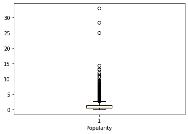

```python
#we will plot a boxplot to visualize the distribution
plt.boxplot(movie_dataset["popularity"])
plt.xlabel("Popularity");
```

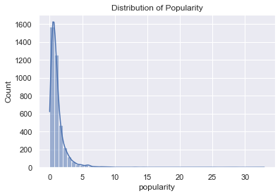

```python
#we will plot a histogram showing the distribution
sns.set(style="darkgrid")
sns.histplot(data=movie_dataset,x=movie_dataset["popularity"], kde= True, bins=50)
plt.title("Distribution of Popularity");
```

### Research Question 2 (What is the relationship between Budget and Popularity?)

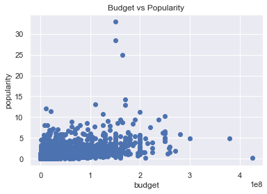

```python
#Is there are a relationship between budget and movie popularity. To find out will plot a scatter plot and find the correlation
plt.scatter(movie_dataset["budget"],movie_dataset["popularity"])
plt.xlabel("budget")
plt.ylabel("popularity")
plt.title("Budget vs Popularity");
```

```python
movie_dataset["budget"].corr(movie_dataset["popularity"])
```

```
0.4465633690496872
```

### Research Question 3 (What is the relationship between Genre and Popularity?)

```python
#will look at our Genres column
movie_dataset.genres.head(2)
```

```
0    Action|Adventure|Science Fiction|Thriller
1    Action|Adventure|Science Fiction|Thriller
Name: genres, dtype: object
```

```python
#The genre columns contains more than one genre, will separate the genres into distinct and unique attribute of each movies
movie_dataset["genres"]= movie_dataset["genres"].str.replace("|",",",regex=False)
```

```python
#source code for spliting https://programmer.ink/think/pandas-how-do-i-split-text-in-a-column-into-multiple-lines-python.html
movie_dataset2 = movie_dataset.drop("genres", axis=1,).join(movie_dataset["genres"].str.split(",",expand=True).stack().reset_index(level=1, drop=True).rename("genres")).reset_index()
```

```python
movie_dataset2.head(10)
```

|  | index | id | imdb_id | popularity | budget | revenue | original_title | cast | director | overview | runtime | release_date | vote_count | vote_average | release_year | budget_adj | revenue_adj | genres |
| --- | --- | --- | --- | --- | --- | --- | --- | --- | --- | --- | --- | --- | --- | --- | --- | --- | --- | --- |
| 0 | 0 | 135397 | tt0369610 | 32.985763 | 150000000 | 1513528810 | Jurassic World | Chris Pratt\|Bryce Dallas Howard\|Irrfan Khan\|Vi... | Colin Trevorrow | Twenty-two years after the events of Jurassic ... | 124 | 6/9/15 | 5562 | 6.5 | 2015 | 1.379999e+08 | 1.392446e+09 | Action |
| 1 | 0 | 135397 | tt0369610 | 32.985763 | 150000000 | 1513528810 | Jurassic World | Chris Pratt\|Bryce Dallas Howard\|Irrfan Khan\|Vi... | Colin Trevorrow | Twenty-two years after the events of Jurassic ... | 124 | 6/9/15 | 5562 | 6.5 | 2015 | 1.379999e+08 | 1.392446e+09 | Adventure |
| 2 | 0 | 135397 | tt0369610 | 32.985763 | 150000000 | 1513528810 | Jurassic World | Chris Pratt\|Bryce Dallas Howard\|Irrfan Khan\|Vi... | Colin Trevorrow | Twenty-two years after the events of Jurassic ... | 124 | 6/9/15 | 5562 | 6.5 | 2015 | 1.379999e+08 | 1.392446e+09 | Science Fiction |
| 3 | 0 | 135397 | tt0369610 | 32.985763 | 150000000 | 1513528810 | Jurassic World | Chris Pratt\|Bryce Dallas Howard\|Irrfan Khan\|Vi... | Colin Trevorrow | Twenty-two years after the events of Jurassic ... | 124 | 6/9/15 | 5562 | 6.5 | 2015 | 1.379999e+08 | 1.392446e+09 | Thriller |
| 4 | 1 | 76341 | tt1392190 | 28.419936 | 150000000 | 378436354 | Mad Max: Fury Road | Tom Hardy\|Charlize Theron\|Hugh Keays-Byrne\|Nic... | George Miller | An apocalyptic story set in the furthest reach... | 120 | 5/13/15 | 6185 | 7.1 | 2015 | 1.379999e+08 | 3.481613e+08 | Action |
| 5 | 1 | 76341 | tt1392190 | 28.419936 | 150000000 | 378436354 | Mad Max: Fury Road | Tom Hardy\|Charlize Theron\|Hugh Keays-Byrne\|Nic... | George Miller | An apocalyptic story set in the furthest reach... | 120 | 5/13/15 | 6185 | 7.1 | 2015 | 1.379999e+08 | 3.481613e+08 | Adventure |
| 6 | 1 | 76341 | tt1392190 | 28.419936 | 150000000 | 378436354 | Mad Max: Fury Road | Tom Hardy\|Charlize Theron\|Hugh Keays-Byrne\|Nic... | George Miller | An apocalyptic story set in the furthest reach... | 120 | 5/13/15 | 6185 | 7.1 | 2015 | 1.379999e+08 | 3.481613e+08 | Science Fiction |
| 7 | 1 | 76341 | tt1392190 | 28.419936 | 150000000 | 378436354 | Mad Max: Fury Road | Tom Hardy\|Charlize Theron\|Hugh Keays-Byrne\|Nic... | George Miller | An apocalyptic story set in the furthest reach... | 120 | 5/13/15 | 6185 | 7.1 | 2015 | 1.379999e+08 | 3.481613e+08 | Thriller |
| 8 | 2 | 262500 | tt2908446 | 13.112507 | 110000000 | 295238201 | Insurgent | Shailene Woodley\|Theo James\|Kate Winslet\|Ansel... | Robert Schwentke | Beatrice Prior must confront her inner demons ... | 119 | 3/18/15 | 2480 | 6.3 | 2015 | 1.012000e+08 | 2.716190e+08 | Adventure |
| 9 | 2 | 262500 | tt2908446 | 13.112507 | 110000000 | 295238201 | Insurgent | Shailene Woodley\|Theo James\|Kate Winslet\|Ansel... | Robert Schwentke | Beatrice Prior must confront her inner demons ... | 119 | 3/18/15 | 2480 | 6.3 | 2015 | 1.012000e+08 | 2.716190e+08 | Science Fiction |

```python
# the number of occurrences of the genre theme in the movies dataset
genre_occurrence =movie_dataset2.groupby("genres")["genres"].count()
genre_occurrence
```

```
genres
Action             1085
Adventure           749
Animation           201
Comedy             1357
Crime               651
Documentary          31
Drama              1753
Family              425
Fantasy             396
Foreign              12
History             129
Horror              463
Music               134
Mystery             344
Romance             666
Science Fiction     519
TV Movie              1
Thriller           1203
War                 119
Western              52
Name: genres, dtype: int64
```

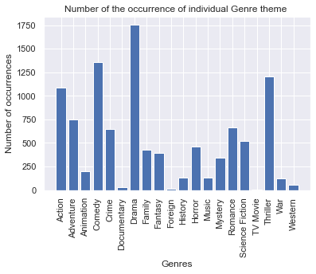

```python
# a barchart for the number of occurrence of the genre theme in the movies dataset
plt.bar(x=genre_occurrence.index, height=genre_occurrence.values)
plt.xlabel("Genres")
plt.ylabel("Number of occurrences")
plt.title("Number of the occurrence of individual Genre theme ")
plt.xticks(rotation=90);
```

```python
#the popularity of each themed genre
genres_popularity =movie_dataset2.groupby("genres")["popularity"].sum()
genres_popularity
```

```
genres
Action             1700.320953
Adventure          1398.902084
Animation           343.835008
Comedy             1374.583912
Crime               731.698494
Documentary           9.802957
Drama              1757.967731
Family              620.093449
Fantasy             694.708555
Foreign               2.187251
History             125.216909
Horror              395.404211
Music               121.902162
Mystery             393.058731
Romance             636.763571
Science Fiction     972.239433
TV Movie              0.273628
Thriller           1515.581815
War                 148.289378
Western              58.980777
Name: popularity, dtype: float64
```

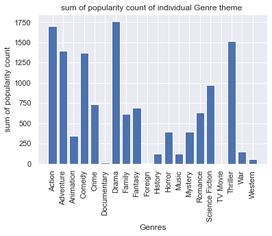

```python
plt.bar(x=genres_popularity.index, height=genres_popularity.values)
plt.xlabel("Genres")
plt.ylabel("sum of popularity count")
plt.title("sum of popularity count of individual Genre theme ")
plt.xticks(rotation=90);
```

```python
#creating a dataframe to hold the number of occurrence and popularity count by genre
genre_data = pd.DataFrame([genre_occurrence.index,genre_occurrence.values,genres_popularity.values])
genre_data = genre_data.T
genre_data.columns=["Genres","No. of Genre Occurrence","Genre Popularity Count"]
genre_data
```

|  | Genres | No. of Genre Occurrence | Genre Popularity Count |
| --- | --- | --- | --- |
| 0 | Action | 1085 | 1700.320953 |
| 1 | Adventure | 749 | 1398.902084 |
| 2 | Animation | 201 | 343.835008 |
| 3 | Comedy | 1357 | 1374.583912 |
| 4 | Crime | 651 | 731.698494 |
| 5 | Documentary | 31 | 9.802957 |
| 6 | Drama | 1753 | 1757.967731 |
| 7 | Family | 425 | 620.093449 |
| 8 | Fantasy | 396 | 694.708555 |
| 9 | Foreign | 12 | 2.187251 |
| 10 | History | 129 | 125.216909 |
| 11 | Horror | 463 | 395.404211 |
| 12 | Music | 134 | 121.902162 |
| 13 | Mystery | 344 | 393.058731 |
| 14 | Romance | 666 | 636.763571 |
| 15 | Science Fiction | 519 | 972.239433 |
| 16 | TV Movie | 1 | 0.273628 |
| 17 | Thriller | 1203 | 1515.581815 |
| 18 | War | 119 | 148.289378 |
| 19 | Western | 52 | 58.980777 |

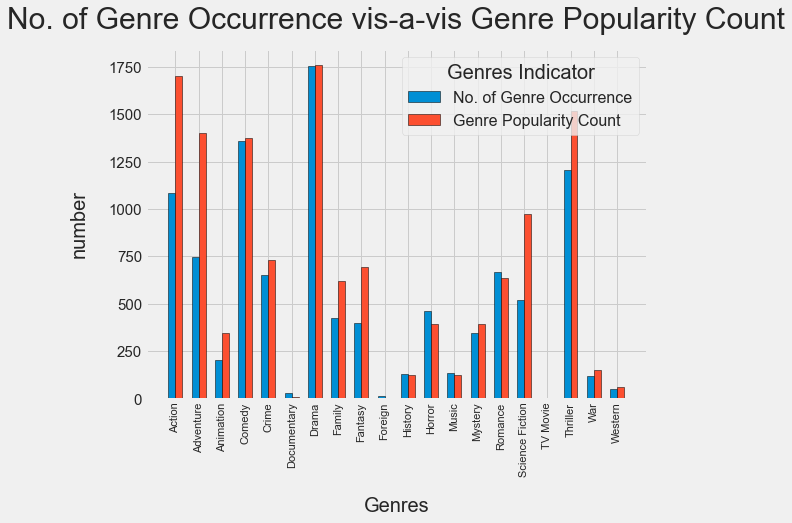

```python
#source code adapted from https://towardsdatascience.com/easy-grouped-bar-charts-in-python-b6161cdd563d
# Visualizing the number of occurrence and popularity by genre
plt.style.use("fivethirtyeight")
fig, ax = plt.subplots(1,1, figsize = (8,6))
label = genre_data["Genres"]
x = np.arange(len(label))
width = 0.3
rect1 = ax.bar(x - width/2,
              genre_data["No. of Genre Occurrence"],
              width = width,
               label = 'No. of Genre Occurrence',
               edgecolor = "black"
              )
rect2 = ax.bar(x + width/2,
              genre_data["Genre Popularity Count"],
              width = width,
              label = 'Genre Popularity Count',
              edgecolor = "black")
ax.set_ylabel("number",
             fontsize = 20,
             labelpad = 20)
ax.set_xlabel("Genres",
             fontsize = 20,
             labelpad =20)
ax.set_title("No. of Genre Occurrence vis-a-vis Genre Popularity Count",
            fontsize = 30,
            pad = 20)
ax.set_xticks(x)
ax.set_xticklabels(label)
ax.legend(title = "Genres Indicator",
         fontsize = 16,
         title_fontsize = 20)
ax.tick_params(axis = "x",
              which = "both",
              labelrotation = 90)
ax.tick_params(axis = "y",
              which = "both",
              labelsize = 15)
```

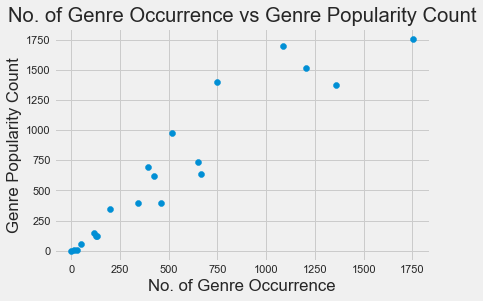

```python
#scatter plot for number of genre occurrence vs genre popularity count
plt.scatter(genre_data["No. of Genre Occurrence"],genre_data["Genre Popularity Count"])
plt.ylabel("Genre Popularity Count")
plt.xlabel("No. of Genre Occurrence")
plt.title("No. of Genre Occurrence vs Genre Popularity Count");
```

```python
#check for the correlation between number of genre-themed occurrence in moviedataset and the genre popularity count
genre_data["No. of Genre Occurrence"].astype(int).corr(genre_data["Genre Popularity Count"].astype(int))
```

```
0.9395458699604236
```

### Research Question 4 (What is the relationship between Runtime and Popularity?)

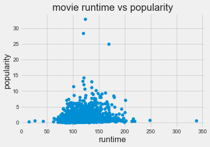

```python
#To find if there is any relationship between movie popularity and runtime lenght
# a scatter plot to show the relationship
plt.scatter(movie_dataset["runtime"],movie_dataset["popularity"])
plt.xlabel("runtime")
plt.ylabel("popularity")
plt.title("movie runtime vs popularity");
```

```python
movie_dataset["runtime"].astype(int).corr(movie_dataset["popularity"].astype(int))
```

```
0.20788550083777832
```

### Research Question 5 (What is the relationship between Vote Count and Popularity?)

[figure not shown]

```python
#scatter plot to show the relation between movie vote count and popularity
plt.scatter(movie_dataset["vote_count"],movie_dataset["popularity"])
plt.xlabel("vote_count")
plt.ylabel("popularity")
plt.title("movie runtime vs popularity");
```

```python
#correlation between movie vote count and movie popularity
movie_dataset["vote_count"].corr(movie_dataset["popularity"])
```

```
0.779985575570126
```

### Research Question 6 (What is the relationship between Popularity and Revenue?)

[figure not shown]

```python
#scatterplot for movie popularity and revenue
plt.scatter(movie_dataset["popularity"],movie_dataset["revenue"])
plt.xlabel("popularity")
plt.ylabel("revenue")
plt.title("movie runtime vs popularity");
```

```python
movie_dataset["popularity"].astype(int).corr(movie_dataset["revenue"].astype(int))
```

```
0.5806802530095827
```

### Research Question 7 (What is the relationship between Popularity and Profit?)

```python
#we will calculate the profit realized for each movie
movie_dataset["profit"] = movie_dataset["revenue"] - movie_dataset["budget"]
movie_dataset["profit"]
```

```
0        1363528810
1         228436354
2         185238201
3        1868178225
4        1316249360
            ...
10822      26236689
10828      10000000
10829       1347000
10835       8000000
10848       6885000
Name: profit, Length: 3849, dtype: int64
```

[figure not shown]

```python
#scatterplot between movie popularity and movie profit
plt.scatter(movie_dataset["popularity"],movie_dataset["profit"])
plt.xlabel("popularity")
plt.ylabel("profit")
plt.title("movie runtime vs popularity");
```

```python
#correlation between movie popularity and movie profit
movie_dataset["popularity"].corr(movie_dataset["profit"])
```

```
0.5960802044338918
```

## Conclusions

> From our analysis we see that:  
> The distribution of the popularity of movies in our dataset is right-skewed.  
> There is a positive correlation of 0.45 between budget and popularity.  
> There is a strong positive correlation of 0.94 between the number of genre occurrence and genre popularity count.  
> There is a weak positive correlation of 0.21 between movie runtime and popularity.  
> There is a strong positive correlation of 0.78 between vote count and popularity of a movie.  
> There is a positive correlation of 0.58 between the popularity of a movie and the revenue generated as well as a positive correlation of 0.59 between movie popularity and profit accurred.

### Recommendations

> Investment into already popular and well accepted genre of movie will most likely yield more profit for movie production companies.  
> It is observed that certain movies were extremely popular as shown from our popularity distribution chart, further studies can be conducted to give insight into why these movies were so popular and its significance in revenue generation.

### References

https://programmer.ink/think/pandas-how-do-i-split-text-in-a-column-into-multiple-lines-python.html  
https://towardsdatascience.com/easy-grouped-bar-charts-in-python-b6161cdd563d

```python
from subprocess import call
call(['python', '-m', 'nbconvert', 'Investigate_a_Dataset.ipynb'])
```